# 2020 US General Election Fraud Analysis

Mick Hittesdorf

11/27/2020

# **1. Introduction**

# **2. Pennsylvania 2020 General Election Results**

[figure not shown]

# **3. Mail-in ballot summary statistics**

[source: opendataPA CommonWealth of Pennsylvania](https://data.pa.gov/Government-Efficiency-Citizen-Engagement/2020-General-Election-Mail-Ballot-Requests-Departm/mcba-yywm)

**NOTE:** This data is no longer publicly available. Access has been blocked with no explanation. Could it be that the data has been useful in identifying instances of fraud in certain Pennsylvania counties? What do the election authorities in Pennsylvania have to hide??

Fortunately, I downloaded this data on 11/11/2020 and it can be found in the ‘data’ directory of this project.

[figure not shown]

## Sample data (10 records):

```r
mail_ballot_requests %>% sample_n(10)
```

| County_Name | Applicant_Party_Designation | Date_of_Birth | Mail_Application_Type | Application_Approved_Date | Application_Return_Date | Ballot_Mailed_Date | Ballot_Returned_Date | State_House_District | State_Senate_District | Congressional_District |
| --- | --- | --- | --- | --- | --- | --- | --- | --- | --- | --- |
| ADAMS | R | 08/31/2000 | OLREGV | 09/26/2020 | 09/26/2020 | 10/03/2020 | NA | 91ST LEGISLATIVE DISTRICT | 33RD SENATORIAL DISTRICT | 13TH CONGRESSIONAL DISTRICT |
| WASHINGTON | I | 10/05/1987 | MAILIN | 10/02/2020 | 10/02/2020 | 10/08/2020 | 10/17/2020 | 40TH LEGISLATIVE DISTRICT | 37TH SENATORIAL DISTRICT | 14TH CONGRESSIONAL DISTRICT |
| PHILADELPHIA | D | 05/17/1946 | MAILIN | 09/25/2020 | 09/25/2020 | 10/06/2020 | 10/18/2020 | 198TH LEGISLATIVE DISTRICT | 3RD SENATORIAL DISTRICT | 3RD CONGRESSIONAL DISTRICT |
| CRAWFORD | R | 12/18/1954 | OLMAILV | 05/15/2020 | 05/15/2020 | 09/30/2020 | 10/29/2020 | 6TH LEGISLATIVE DISTRICT | 50TH SENATORIAL DISTRICT | 16TH CONGRESSIONAL DISTRICT |
| PHILADELPHIA | D | 09/24/1995 | OLMAILV | 05/19/2020 | 05/19/2020 | 09/30/2020 | 10/22/2020 | 194TH LEGISLATIVE DISTRICT | 7TH SENATORIAL DISTRICT | 3RD CONGRESSIONAL DISTRICT |
| ADAMS | D | 11/16/1989 | OLREGV | 09/30/2020 | 09/30/2020 | 10/03/2020 | NA | 91ST LEGISLATIVE DISTRICT | 33RD SENATORIAL DISTRICT | 13TH CONGRESSIONAL DISTRICT |
| DAUPHIN | R | 09/28/1967 | OLMAILV | 09/29/2020 | 09/29/2020 | 10/07/2020 | 10/30/2020 | 106TH LEGISLATIVE DISTRICT | 48TH SENATORIAL DISTRICT | 10TH CONGRESSIONAL DISTRICT |
| DELAWARE | D | 07/25/2002 | OLMAILV | 09/01/2020 | 09/01/2020 | 10/03/2020 | 10/21/2020 | 161ST LEGISLATIVE DISTRICT | 26TH SENATORIAL DISTRICT | 5TH CONGRESSIONAL DISTRICT |
| LEBANON | NO | 11/01/1953 | OLREGV | 09/24/2020 | 09/24/2020 | 10/07/2020 | 10/26/2020 | 101ST LEGISLATIVE DISTRICT | 48TH SENATORIAL DISTRICT | 9TH CONGRESSIONAL DISTRICT |
| ALLEGHENY | D | 10/05/1953 | CVO | 03/03/2020 | 03/03/2020 | 09/19/2020 | 10/22/2020 | 28TH LEGISLATIVE DISTRICT | 38TH SENATORIAL DISTRICT | 17TH CONGRESSIONAL DISTRICT |

```r
NA
```

## Types of absentee ballots in Pennsylvania

```r
mail_ballot_requests %>% group_by(Mail_Application_Type) %>% count() %>% arrange(desc(n))
```

| Mail_Application_Type | n |
| --- | --- |
| OLMAILV | 1412751 |
| MAILIN | 1244610 |
| OLREGV | 329900 |
| REG | 58442 |
| F | 12114 |
| CVO | 11412 |
| M | 10789 |
| OLMAILNV | 5751 |
| OLREGNV | 5025 |
| C | 4627 |

[output cut: 8 more lines]

## Total mail-in ballots by county with overall total

All ballots without a return date are excluded in the table below. Note that the total number of mail-in ballots is less than that reported on the Pennsylvania election results Web site (2,553,094 < 2,589,242). The difference is 36148 ballots, which is 1.4% of the total.

It is possible that these ballots were rejected for a valid reason (i.e. spoiled ballots).

```r
mail_ballot_requests %>% filter(!is.na(Ballot_Returned_Date)) %>% group_by(County_Name) %>% summarise(n = n()) %>% mutate(total = sum(n)) %>% mutate(percent = round(100 * n/total,1)) %>% arrange(desc(n))
```

| County_Name | n | total | percent |
| --- | --- | --- | --- |
| PHILADELPHIA | 351304 | 2553094 | 13.8 |
| ALLEGHENY | 346273 | 2553094 | 13.6 |
| MONTGOMERY | 238193 | 2553094 | 9.3 |
| BUCKS | 154807 | 2553094 | 6.1 |
| CHESTER | 139161 | 2553094 | 5.5 |
| DELAWARE | 111350 | 2553094 | 4.4 |
| LANCASTER | 89681 | 2553094 | 3.5 |
| YORK | 76216 | 2553094 | 3.0 |
| LEHIGH | 73295 | 2553094 | 2.9 |
| NORTHAMPTON | 72882 | 2553094 | 2.9 |

[output cut: 57 more lines]

```r
NA
```

## Number of mail-in ballots by party affiliation

```r
mail_ballot_requests %>% filter(!is.na(Ballot_Returned_Date)) %>% group_by(Applicant_Party_Designation) %>% summarise(n = count()) %>% mutate(total = sum(n)) %>% mutate(percent = round(100 * n/total,1)) %>% arrange(desc(n))
```

| Applicant_Party_Designation | n | total | percent |
| --- | --- | --- | --- |
| D | 1665503 | 2553094 | 65.2 |
| R | 600455 | 2553094 | 23.5 |
| NF | 199161 | 2553094 | 7.8 |
| I | 26562 | 2553094 | 1.0 |
| NOP | 19663 | 2553094 | 0.8 |
| NO | 15478 | 2553094 | 0.6 |
| LN | 7591 | 2553094 | 0.3 |
| OTH | 6677 | 2553094 | 0.3 |
| NON | 5390 | 2553094 | 0.2 |
| GR | 2388 | 2553094 | 0.1 |

[output cut: 176 more lines]

# **4. Age analysis**

## Number of ballots returned by age

The birth date of 1/1/1800 is used to protected the privacy of certain registered voters (i.e. age = 220)

```r
mail_ballot_requests %>% filter(!is.na(Ballot_Returned_Date)) %>% mutate(Age = floor(datediff(current_date(), to_date(Date_of_Birth, 'MM/dd/yyyy'))/365.25)) %>% group_by(Age) %>% tally() %>% arrange(desc(Age))
```

| Age | n |
| --- | --- |
| 220 | 38 |
| 170 | 1 |
| 166 | 1 |
| 130 | 1 |
| 126 | 2 |
| 125 | 1 |
| 124 | 1 |
| 122 | 1 |
| 120 | 11 |
| 119 | 6 |

[output cut: 100 more lines]

```r
NA
```

## Total number of ballots returned by those 85 years of age or older

```r
mail_ballot_requests %>% filter(!is.na(Ballot_Returned_Date)) %>% mutate(Age = floor(datediff(current_date(), to_date(Date_of_Birth, 'MM/dd/yyyy'))/365.25)) %>% filter(Age >= 85) %>% tally()
```

| n |
| --- |
| 128167 |

```r
NA
```

# **5. Ballot turnaround**

## Total ballots processed in one day or less

It is very unlikely that a ballot could be mailed, received, marked by the voter, mailed back and processed in one day or less. As such, these ballots should be audited or summarily rejected.

```r
mail_ballot_requests %>% filter(!is.na(Ballot_Returned_Date)) %>% mutate(Ballot_Turnaround_Days = datediff(to_date(Ballot_Returned_Date, 'MM/dd/yyyy'), to_date(Ballot_Mailed_Date, 'MM/dd/yyyy'))) %>% filter(Ballot_Turnaround_Days <= 1) %>% tally()
```

| n |
| --- |
| 109421 |

## Ballots processed in more than 1 day by party designation

NOTE: assumes ballots take more than one day to completely process, so such ballots should be rejected.

```r
mail_ballot_requests %>% filter(!is.na(Ballot_Returned_Date)) %>% mutate(Ballot_Turnaround_Days = datediff(to_date(Ballot_Returned_Date, 'MM/dd/yyyy'), to_date(Ballot_Mailed_Date, 'MM/dd/yyyy'))) %>% filter(Ballot_Turnaround_Days > 1) %>%  group_by(Applicant_Party_Designation) %>% summarise(n = n()) %>% mutate(total = sum(n)) %>% mutate(percent = round(100 * n/total,1)) %>% arrange(desc(n))
```

| Applicant_Party_Designation | n | total | percent |
| --- | --- | --- | --- |
| D | 1587790 | 2434668 | 65.2 |
| R | 573536 | 2434668 | 23.6 |
| NF | 189332 | 2434668 | 7.8 |
| I | 25147 | 2434668 | 1.0 |
| NOP | 18864 | 2434668 | 0.8 |
| NO | 14950 | 2434668 | 0.6 |
| LN | 7298 | 2434668 | 0.3 |
| OTH | 6302 | 2434668 | 0.3 |
| NON | 5161 | 2434668 | 0.2 |
| GR | 2296 | 2434668 | 0.1 |

[output cut: 171 more lines]

```r
NA
NA
```

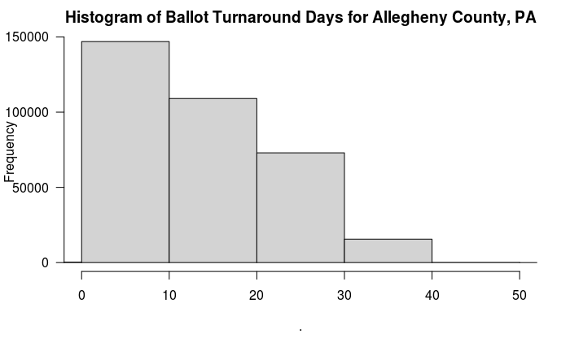

```r
mail_ballot_requests %>% filter(County_Name == 'ALLEGHENY') %>% mutate(Ballot_Turnaround_Days = datediff(to_date(Ballot_Returned_Date, 'MM/dd/yyyy'), to_date(Ballot_Mailed_Date, 'MM/dd/yyyy'))) %>% pull(Ballot_Turnaround_Days) %>% hist(main = "Histogram of Ballot Turnaround Days for Allegheny County, PA", xlim = c(0, 50), las=1)
```

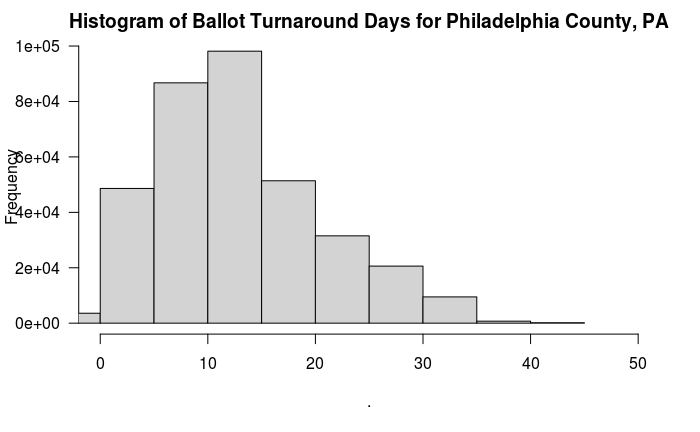

```r
mail_ballot_requests %>% filter(County_Name == 'PHILADELPHIA') %>% mutate(Ballot_Turnaround_Days = datediff(to_date(Ballot_Returned_Date, 'MM/dd/yyyy'), to_date(Ballot_Mailed_Date, 'MM/dd/yyyy'))) %>% pull(Ballot_Turnaround_Days) %>% hist(main = "Histogram of Ballot Turnaround Days for Philadelphia County, PA", xlim = c(0, 50), las=1)
```

```r
mail_ballot_requests %>% filter(Applicant_Party_Designation %in% c('R', 'D','IND')) %>% mutate(Ballot_Turnaround_Days = datediff(to_date(Ballot_Returned_Date, 'MM/dd/yyyy'), to_date(Ballot_Mailed_Date, 'MM/dd/yyyy')), Age = floor(datediff(current_date(), to_date(Date_of_Birth, 'MM/dd/yyyy'))/365)) %>% filter(Ballot_Turnaround_Days <= 1) %>% group_by(Applicant_Party_Designation) %>% summarise(n = count(), avg_age = round(mean(Age)))
```

```
Missing values are always removed in SQL.
Use `mean(x, na.rm = TRUE)` to silence this warning
```

| Applicant_Party_Designation | n | avg_age |
| --- | --- | --- |
| IND | 9 | 61 |
| R | 24099 | 60 |
| D | 72691 | 53 |

```r
mail_ballot_requests %>% mutate(Ballot_Turnaround_Days = datediff(to_date(Ballot_Returned_Date, 'MM/dd/yyyy'), to_date(Ballot_Mailed_Date, 'MM/dd/yyyy'))) %>% filter(Ballot_Turnaround_Days <= 1) %>% group_by(County_Name) %>% summarise(n = count()) %>% mutate(total = sum(n)) %>% mutate(percent = round(100* (n/total),1)) %>% arrange(desc(n))
```

| County_Name | n | total | percent |
| --- | --- | --- | --- |
| PHILADELPHIA | 24925 | 109421 | 22.8 |
| LEHIGH | 23155 | 109421 | 21.2 |
| CHESTER | 7075 | 109421 | 6.5 |
| MONTGOMERY | 4750 | 109421 | 4.3 |
| CUMBERLAND | 3713 | 109421 | 3.4 |
| NORTHAMPTON | 3450 | 109421 | 3.2 |
| BUCKS | 3303 | 109421 | 3.0 |
| LANCASTER | 2864 | 109421 | 2.6 |
| GREENE | 2539 | 109421 | 2.3 |
| DAUPHIN | 2359 | 109421 | 2.2 |

[output cut: 57 more lines]

```r
mail_ballot_requests %>% mutate(Ballot_Turnaround_Days = datediff(to_date(Ballot_Returned_Date, 'MM/dd/yyyy'), to_date(Ballot_Mailed_Date, 'MM/dd/yyyy'))) %>% filter(Ballot_Turnaround_Days <= 2) %>% mutate(Age = floor(datediff(current_date(), to_date(Date_of_Birth, 'MM/dd/yyyy'))/365))
```

| County_Name | Applicant_Party_Designation | Date_of_Birth | Mail_Application_Type | Application_Approved_Date | Application_Return_Date | Ballot_Mailed_Date | Ballot_Returned_Date | State_House_District | State_Senate_District | Congressional_District | Ballot_Turnaround_Days | Age |
| --- | --- | --- | --- | --- | --- | --- | --- | --- | --- | --- | --- | --- |
| FAYETTE | D | 07/29/1951 | OLMAILV | 04/27/2020 | 04/27/2020 | 10/27/2020 | 10/29/2020 | 52ND LEGISLATIVE DISTRICT | 32ND SENATORIAL DISTRICT | 14TH CONGRESSIONAL DISTRICT | 2 | 69 |
| PHILADELPHIA | D | 06/23/1952 | MAILIN | 10/25/2020 | 10/25/2020 | 10/26/2020 | 10/27/2020 | 203RD LEGISLATIVE DISTRICT | 4TH SENATORIAL DISTRICT | 3RD CONGRESSIONAL DISTRICT | 1 | 68 |
| PHILADELPHIA | D | 09/16/1982 | MAILIN | 10/25/2020 | 10/25/2020 | 10/26/2020 | 10/27/2020 | 173RD LEGISLATIVE DISTRICT | 5TH SENATORIAL DISTRICT | 2ND CONGRESSIONAL DISTRICT | 1 | 38 |
| LEHIGH | D | 05/05/1960 | MAILIN | 08/25/2020 | 08/25/2020 | 10/19/2020 | 10/15/2020 | 187TH LEGISLATIVE DISTRICT | 16TH SENATORIAL DISTRICT | 7TH CONGRESSIONAL DISTRICT | -4 | 60 |
| LEHIGH | D | 07/20/1956 | MAILIN | 08/12/2020 | 08/12/2020 | 10/19/2020 | 10/17/2020 | 131ST LEGISLATIVE DISTRICT | 16TH SENATORIAL DISTRICT | 7TH CONGRESSIONAL DISTRICT | -2 | 64 |
| LEHIGH | R | 03/18/1982 | OLMAILV | 04/29/2020 | 04/29/2020 | 10/19/2020 | 10/15/2020 | 183RD LEGISLATIVE DISTRICT | 16TH SENATORIAL DISTRICT | 7TH CONGRESSIONAL DISTRICT | -4 | 38 |
| GREENE | D | 10/24/1955 | OLREGV | 08/06/2020 | 08/06/2020 | 10/19/2020 | 10/13/2020 | 50TH LEGISLATIVE DISTRICT | 46TH SENATORIAL DISTRICT | 14TH CONGRESSIONAL DISTRICT | -6 | 65 |
| PHILADELPHIA | D | 10/21/1962 | MAILIN | 10/20/2020 | 10/20/2020 | 10/20/2020 | 10/21/2020 | 172ND LEGISLATIVE DISTRICT | 5TH SENATORIAL DISTRICT | 2ND CONGRESSIONAL DISTRICT | 1 | 58 |
| NORTHAMPTON | D | 11/28/1985 | MAILIN | 10/26/2020 | 10/26/2020 | 10/26/2020 | 10/27/2020 | 138TH LEGISLATIVE DISTRICT | 18TH SENATORIAL DISTRICT | 7TH CONGRESSIONAL DISTRICT | 1 | 35 |
| LEHIGH | D | 05/15/1984 | OLREGV | 09/22/2020 | 09/22/2020 | 10/19/2020 | 10/20/2020 | 133RD LEGISLATIVE DISTRICT | 18TH SENATORIAL DISTRICT | 7TH CONGRESSIONAL DISTRICT | 1 | 36 |

[output cut: 990 more lines]